# Charleston Sea Level Rise

Dan McGlinn

2/12/2018

A [recent article](https://www.postandcourier.com/news/slowly-but-surely-south-carolina-s-incredibly-complex-shoreline-is/article_46e18626-cde8-11e6-be82-6393ed1dbe62.html) in the *Post and Courier* on sea level rise got my attention. I think it would be great exercise for my students to examine the raw data. It is quite simple to download historic data for a single station. Unfortunately I found that NOAA’s api only allows you to automate the downloading of water level data for the past 30 days. Although the great folks at RopenSci have created the R package [`rnoaa`](https://github.com/ropensci/rnoaa) it does not appear that this tool will work for the historic data until NOAA provides long-term search for this data produce on their API.

This data comes from the [NOAA Charleston, Cooper River Entrance, SC - Station ID: 8665530](https://tidesandcurrents.noaa.gov/stationhome.html?id=8665530).

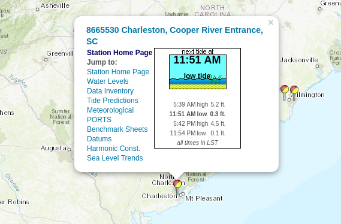

```r
# url for data:
# https://tidesandcurrents.noaa.gov/waterlevels.html?id=8665530&units=standard&bdate=19211001&edate=20501101&timezone=GMT&datum=MLLW&interval=m&action=data
# metadata on data fields:
# https://tidesandcurrents.noaa.gov/datum_options.html
water_ht <- read.csv('./data/CO-OPS__8665530__ml.csv')
head(water_ht)
```

```
##   Year Month Highest MHHW   MHW   MSL   MTL    MLW MLLW DTL GT    MN DHQ
## 1 1921    10   1.992   NA 1.571 0.824 0.788  0.004   NA  NA NA 1.567  NA
## 2 1921    11   1.931   NA 1.467 0.730 0.690 -0.087   NA  NA NA 1.554  NA
## 3 1921    12   1.900   NA 1.431 0.684 0.651 -0.133   NA  NA NA 1.564  NA
## 4 1922     1   1.717   NA 1.309 0.559 0.523 -0.261   NA  NA NA 1.570  NA
## 5 1922     2   1.870   NA 1.403 0.644 0.605 -0.194   NA  NA NA 1.597  NA
## 6 1922     3   1.839   NA 1.391 0.629 0.599 -0.197   NA  NA NA 1.588  NA
##   DLQ  HWI  LWI Lowest Inferred
## 1  NA 0.84 6.91 -0.325        0
## 2  NA 0.69 6.84 -0.691        0
## 3  NA 0.63 6.74 -0.508        0
## 4  NA 0.66 6.78 -0.873        0
## 5  NA 0.62 6.67 -0.691        0
## 6  NA 0.59 6.71 -0.630        0
```

```r
# make a date variable
water_ht$date <- with(water_ht,
                      as.Date(paste(Year, Month, 01, sep = "-")))
```

Let’s now examine some of the long and short term trends in the data:

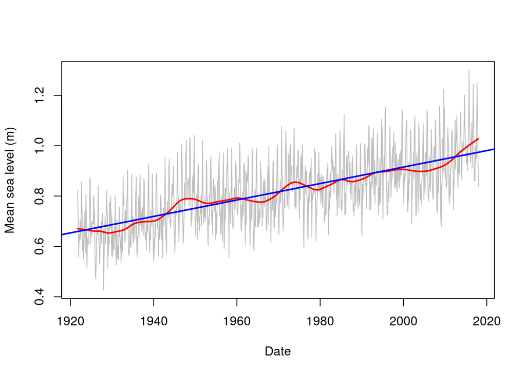

```r
msl_lm = lm(MSL ~ date, data = water_ht)

plot(MSL ~ date, data = water_ht, type = 'l', col = 'grey',
     xlab = 'Date', ylab = 'Mean sea level (m)')
lines(with(water_ht, lowess(date, MSL, f = 0.1)), col = 'red', lwd=2)
abline(msl_lm, col = 'blue', lwd = 2)
```

Clearly there is a long-term positive trend in increasing sea level rise that appears to be accelerating in the last decade or so.

Acknowledgments: Jim Morris kindly pointed me towards the NOAA datasets that are available online, and provided further insight into trends in sea level rise can be best estimated.